# 3 Ego-Network Variables

**Note**

**Overall Summary**: This phase of data cleaning will

- prepare data for creating ego-network datasets
- correct alter variable names
- correct alter values

## 3.1 Preparations

### Packages

```r
pacman::p_load(tidyverse, haven, here, labelled, egor, igraph)
```

## 3.2 Import Dataset

```r
p3_data <- readRDS("work_data/p2_data.Rds")
```

## 3.3 Prepare Data

### Create EgoID variable

```r
p3_data <- p3_data |>
  mutate(egoid = 1:n()) |>
  select(egoid, everything())
```

### Remove All Text Variables

EgoR package cannot create an ego network data if text variables/values exist. Thus if any variables contain text, we will drop.

```r
p3_data <- p3_data |>
  select(-contains("TEXT"))
```

## 3.4 Correct Variable Names

```r
p3_data <- p3_data %>%
  rename(
  # NEW var = OLD var
  alt_convs_2 = alt_cons_2,
  alt_ra_2 = alr_ra_2,
  alt_ra_3 = alr_ra_3
  )
```

## 3.5 Correct Alter-Alter Ties

The value labels are coded in a manner that will bias how we calculate ego network characteristics.

```r
get_variable_labels(p3_data$ap1_2)
```

```
[1] "Do [QID1089-ChoiceTextEntryValue-1] and [QID1089-ChoiceTextEntryValue-2] talk to each other independently of you? In other words, do they have a relationship independently of you? For example, your parent and sibling might talk, but your parent and coworker might not."
```

```r
get_value_labels(p3_data$ap1_2)
```

```
                  Yes                    No          I don't know
                    1                     2                     3
Choose Not to Respond
                    4
```

As you can see, `No = 2` while `Yes = 1`. However, when we calculate the sum, we want to make sure that we only count the `Yes`’s, thus it makes more sense to code No as 0, and Yes as 1.

```r
p3_data <- p3_data |>
  mutate(across(contains("ap1_") | contains("ap2_") | contains("ap3_") | contains("ap4_") | contains("ap5_") | contains("ap6_") | contains("ap7_") | contains("ap8_") | contains("ap9_"), ~ifelse(. == 2, 0, .)))
```

The code above specifies: `If value is equal to 2, then code as 0. If the condition is not true, leave as is`.

## 3.6 Create Ego Network Data

Let’s create our ego network data!

```r
ego_object <- onefile_to_egor(
  egos = p3_data,
  ID.vars = list(ego = "egoid"),
  attr.start.col = "alt_rel_1", # Name of Variable with the first alter attribute
  attr.end.col = "alt_smv_conc_10", # Name of variable with last alter attribute
  max.alters = 10, # Number of maximum alters that were named by participants
  aa.first.var = "ap1_2") # Name of first alter-alter variable


saveRDS(ego_object, here("work_data/egor_object.Rds"))
```

### Create Merged Dataset

Having created the three different datasets, we want to create a dataset that merges the ego and alter data.

```r
p3.1_data <- ego_object$ego

p3.2_data <- ego_object$alter
```

What we’ve done above is create two datasets based on ego and alter (respectively). Now using the .egoID variable, lets merge these two datasets together.

```r
p3.3_data <- p3.2_data %>%
  left_join(p3.1_data, by = ".egoID")
```

## 3.7 Create Network Characteristic Variables

A weight is invalid if it is empty, which signifies missing data. As such, we will remove those values. This is also **essential** as a weight must range between 0 to 1 to calculate network characteristic variables (e.g., network density).

```r
ego_object <- ego_object |>
  activate(aatie) |>
  filter(weight != "")
```

### Network Density

```r
data_density <- ego_density(ego_object)
data_density$.egoID <- as.numeric(data_density$.egoID)
data_density$density <- as.numeric(data_density$density)
psych::describe(data_density$density)
```

```
   vars   n mean   sd median trimmed  mad min max range skew kurtosis   se
X1    1 954 0.34 0.26   0.29    0.31 0.26   0   1     1 0.79     0.04 0.01
```

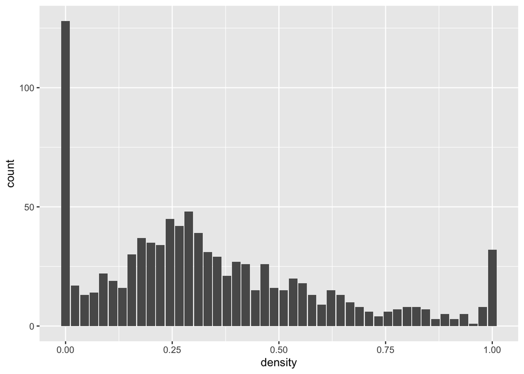

```r
data_density %>%
  ggplot(aes(x = density)) +
  geom_bar()
```

Here we can see that the average network density is 0.34 (SD = 0.26). Having created this variable, we want to merge with the larger dataset we are working with.

```r
p3.3_data$.egoID <- as.numeric(p3.3_data$.egoID)
p3.4_data <- left_join(p3.3_data, data_density, by = ".egoID")
```

### Create Alter Sum

Next, let’s create a variable for each ego that counts how many alters they named.

We do this by counting the distinct number of observations for each ego.

```r
p3.3_data <- p3.3_data %>%
  group_by(.egoID) %>%
  mutate(alt_sum = n_distinct(.altID)) %>%
  ungroup()

psych::describe(p3.3_data$alt_sum)
```

```
   vars    n mean sd median trimmed mad min max range skew kurtosis se
X1    1 9540   10  0     10      10   0  10  10     0  NaN      NaN  0
```

Looks like everyone named 10 alters.

`alt_sum` was added to `p3.3_data` after `p3.4_data` was already created, so it needs to be explicitly merged in.

```r
p3.4_data <- left_join(p3.4_data, p3.3_data %>% distinct(.egoID, alt_sum), by = ".egoID")
```

## 3.8 Create igraph Object

To create component variables, we need to convert the egoR object into an igraph object.

```r
igraphs <- as_igraph(ego_object)
saveRDS(igraphs, here("work_data/igraphs.Rds"))
```

Here we can previous whan the igraph output looks like for Ego1.

```r
print(igraphs[[1]])
```

[output not shown]

### Network Components (Fragmentation)

`components()` identifies clusters of alters who are connected to each other, independent of ego. An ego whose alters split into several components has a *fragmented* network — the alters don’t all know one another, so ego sits at the center of several disconnected social worlds. An ego with one component has a fully reachable network, at least in terms of connectivity (this doesn’t necessarily mean the network is *dense*).

We calculate, for each ego: - the number of components, and - the proportion of alters who fall in the largest component (a common fragmentation index — closer to 1 means most alters are reachable from one another; lower values indicate a more splintered network).

```r
data_components <- tibble(
  .egoID = sapply(igraphs, function(g) graph_attr(g, ".egoID")),
  n_components = sapply(igraphs, function(g) components(g)$no),
  largest_component_size = sapply(igraphs, function(g) max(components(g)$csize)),
  prop_largest_component = sapply(igraphs, function(g)
    max(components(g)$csize) / vcount(g))
)

data_components$.egoID <- as.numeric(data_components$.egoID)
psych::describe(data_components[, c("n_components", "prop_largest_component")])
```

```
                       vars   n mean   sd median trimmed  mad min max range
n_components              1 954 3.80 3.09    3.0    3.38 2.97 1.0  10   9.0
prop_largest_component    2 954 0.65 0.32    0.7    0.67 0.44 0.1   1   0.9
                        skew kurtosis   se
n_components            1.00    -0.35 0.10
prop_largest_component -0.41    -1.17 0.01
```

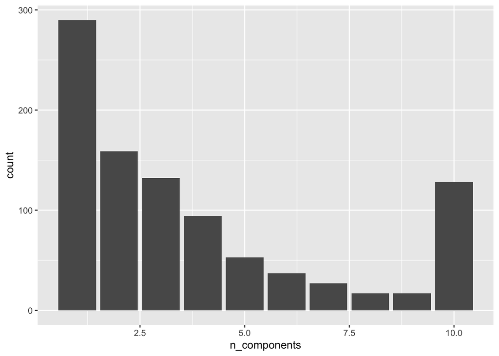

```r
data_components %>%
  ggplot(aes(x = n_components)) +
  geom_bar()
```

Having created these variables, we merge them into the larger dataset.

```r
p3.4_data <- left_join(p3.4_data, data_components, by = ".egoID")
```

### Network Centrality

Centrality measures describe *positions of individual alters* within an ego’s network, rather than the network as a whole. To turn them into ego-level variables, we take two approaches: (1) summarize the alter-level scores (mean, max) across each ego’s alters, and (2) use igraph’s *centralization* functions, which collapse alter-level centrality into a single Freeman-style graph index — how dominated the network is by one or a few central alters (0 = evenly distributed, 1 = a pure hub/star structure).

**Betweenness** identifies “broker” alters — those who sit on the shortest path between two other alters. A network with high betweenness centralization is one where a single alter (or few) bridges otherwise-separate parts of ego’s social world.

**Edge betweenness** applies the same logic to ties rather than alters — it flags which alter-alter connections are critical bridges holding the network together (removing them would disconnect otherwise-linked parts of the network).

**Closeness** captures how quickly each alter can be reached from every other alter on average. High closeness centralization means the network revolves around one or a few well-embedded alters, rather than everyone being roughly equidistant from one another.

```r
data_centrality <- tibble(
  .egoID = sapply(igraphs, function(g) graph_attr(g, ".egoID")),

  # Alter-level betweenness, summarized to the ego level
  mean_betweenness = sapply(igraphs, function(g) mean(betweenness(g), na.rm = TRUE)),
  max_betweenness  = sapply(igraphs, function(g) max(betweenness(g), na.rm = TRUE)),

  # Edge-level betweenness, summarized to the ego level
  mean_edge_betweenness = sapply(igraphs, function(g) mean(edge_betweenness(g), na.rm = TRUE)),

  # Alter-level closeness, summarized to the ego level
  mean_closeness = sapply(igraphs, function(g) mean(closeness(g), na.rm = TRUE)),

  # Graph-level centralization indices (Freeman-style)
  centralization_betweenness = sapply(igraphs, function(g) centr_betw(g)$centralization),
  centralization_closeness   = sapply(igraphs, function(g) centr_clo(g)$centralization)
)

data_centrality$.egoID <- as.numeric(data_centrality$.egoID)
psych::describe(data_centrality[, c("centralization_betweenness", "centralization_closeness")])
```

```
                           vars   n mean   sd median trimmed  mad min  max
centralization_betweenness    1 954 0.02 0.03   0.01    0.02 0.02   0 0.23
centralization_closeness      2   0  NaN   NA     NA     NaN   NA Inf -Inf
                           range skew kurtosis se
centralization_betweenness  0.23  1.9     4.38  0
centralization_closeness    -Inf   NA       NA NA
```

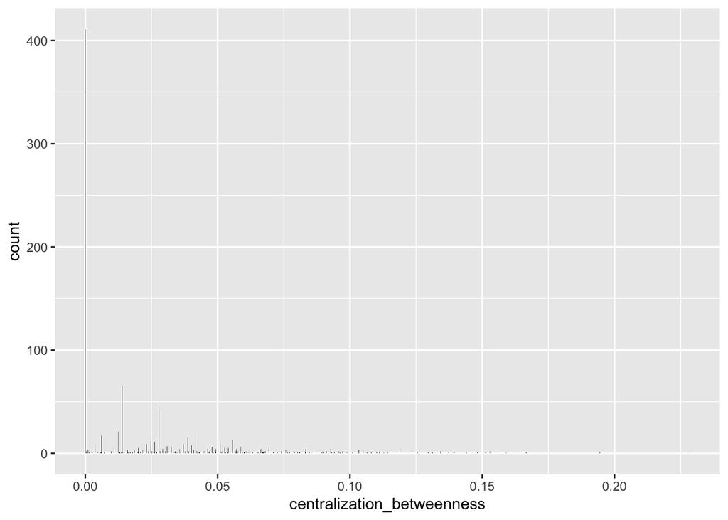

```r
data_centrality %>%
  ggplot(aes(x = centralization_betweenness)) +
  geom_bar()
```

Having created these variables, we merge them into the larger dataset.

```r
p3.4_data <- left_join(p3.4_data, data_centrality, by = ".egoID")
```

## 3.9 Create Separate Datasets

Now that all ego-level network characteristics have been merged in, let’s split the data into the three datasets we actually want to work with: ego data (one row per ego), ego-alter data (one row per alter, with ego attributes attached), and alter-alter data (the tie list).

### Ego Data

```r
p3_ego_data <- p3.1_data %>%
  mutate(.egoID = as.numeric(.egoID)) %>%
  left_join(data_density, by = ".egoID") %>%
  left_join(data_components, by = ".egoID") %>%
  left_join(data_centrality, by = ".egoID") %>%
  left_join(p3.3_data %>% distinct(.egoID, alt_sum), by = ".egoID")
```

### Ego-Alter Data

`p3.4_data` already *is* our ego-alter dataset — one row per alter, with the ego’s survey responses and all ego-level network characteristics attached to every alter row.

```r
p3_ego_alter_data <- p3.4_data
```

### Alter-Alter Data

```r
p3_alter_alter_data <- ego_object$aatie
```

## 3.10 Save Results

```r
saveRDS(p3.4_data, "work_data/p3_data.Rds")
saveRDS(p3_ego_data, "work_data/p3_ego_data.Rds")
```

### Codebooks

We will generate a .txt codebook for the ego data and ego-alter data (the alter-alter tie list is just IDs and a weight, so it doesn’t need one).

```r
memisc::Write(memisc::codebook(p3_ego_data),
      file = "output_txt/p3_ego_data_codebook.txt")

memisc::Write(memisc::codebook(p3_ego_alter_data),
      file = "output_txt/p3_ego_alter_data_codebook.txt")

writexl::write_xlsx(p3_ego_data, "work_data/p3_ego_data.xlsx")
writexl::write_xlsx(p3_ego_alter_data, "work_data/p3_ego_alter_data.xlsx")
writexl::write_xlsx(p3_alter_alter_data, "work_data/p3_alter_alter_data.xlsx")
```